# Trading Strategy: Analysis and Classification of Senate Trade Disclosures <> 1. Introduction 2. Datasets 3. Exploratory Data Analysis 4. Modeling 5. Conclusion

# 1. Introduction <>

# **Project Description**

On December 2nd, 2022, Pelosi sold an additional 20,000 shares of Visa, valued at ~$4M.

Back in 2008, Visa offered her husband a "VIP cut of the IPO" at $11/share

Since then, $V is up ~1900%

Just days after her sale of 20,000 shares, the Credit Card Competition Act, legislation aiming to break up the Visa-MA duopoly, was introduced to the House. If passed, Visa would no longer monopolize CC fees.

The Stock Trading on Congressional Knowledge Act requires U.S. Senators to publicly disclose all of their financial transaction within 45 days. In this project we analyze these disclosures, monitor trade performance in the time following transaction, and build a classification to determine, upon disclosure, whether a senator's trade will outperform the S&P500.

# **Project Goals**

In this project, we hope to analyze the performance of senators' trades, look into any recurring patterns or trends in the dataset, and hopefully be able to classify whether a newly-disclosed trade will profitably outperform the market.

## Imports

```python
!pip install yfinance

import pandas as pd
import numpy as np
import matplotlib.pyplot as plt
import seaborn as sns

from bs4 import BeautifulSoup
import json
import requests
from urllib.request import urlopen

import datetime
from datetime import timedelta, date

import yfinance as yf
from threading import Thread

from sklearn.neighbors import KNeighborsClassifier
from sklearn.preprocessing import StandardScaler
from sklearn.neighbors import KNeighborsClassifier
from sklearn.feature_extraction import DictVectorizer
from sklearn.metrics import accuracy_score
from sklearn.metrics import precision_score, recall_score
from sklearn.pipeline import Pipeline
from sklearn.model_selection import cross_val_score
```

```
     |████████████████████████████████| 62 kB 704 kB/s
  Attempting uninstall: requests
    Found existing installation: requests 2.23.0
    Uninstalling requests-2.23.0:
      Successfully uninstalled requests-2.23.0
```

# 2. Datasets <>

## Senate Trade Disclosures

https://senatestockwatcher.com/api

> This dataset contains a full list of nearly 10,000 senate trades from this past decade. Observations document the transaction and disclosure dates, senators, tickers, political party, sector, industry, and amount associated with every disclosed trade.

> Observations document the following features associated with every disclosed trade:
- Senator
- Transaction Date
- Disclosure Date
- Stock Ticker
- Political Party
- Sector

> Below, we insert an additional column, "days between", to quantify the number of days a senator waited before disclosing their trade (remember that the maximum is 45).

```python
# Download Disclosures
disclosures = pd.DataFrame(json.loads(urlopen("https://senate-stock-watcher-data.s3-us-west-2.amazonaws.com/aggregate/all_transactions.json").read().decode('utf-8', 'replace')))

# Drop unessecary columns
disclosures.drop(['owner', 'asset_description', 'comment', 'ptr_link'], axis=1, inplace=True)

# Reformat Dates
disclosures['disclosure_date'] = pd.to_datetime(disclosures['disclosure_date'])
disclosures['transaction_date'] = pd.to_datetime(disclosures['transaction_date'])

# Filter out any non-ETF disclosures
disclosures = disclosures.loc[disclosures["asset_type"] == "Stock"]
disclosures.drop(['asset_type'], axis=1, inplace=True)
disclosures = disclosures.loc[disclosures["type"] != "Exchange"]

# Filter out NaNs
disclosures = disclosures[disclosures['industry'].notnull()]
disclosures = disclosures[disclosures['sector'].notnull()]

# Filter out all trades from this year
disclosures = disclosures.loc[disclosures['disclosure_date'] < '2022-01-01']
disclosures = disclosures.loc[disclosures['disclosure_date'] > '2012-12-31']

# Insert column of days between trade and disclosure
disclosures['days_between'] = (disclosures['disclosure_date'] - disclosures['transaction_date']).dt.days

# Because Zuck decided to complicate our lives
disclosures['ticker'] = disclosures['ticker'].str.replace("FB","META")

# Resetting Index
disclosures.reset_index(inplace=True)
disclosures = disclosures.iloc[:, 1:]
```

```python
disclosures
```

|  | transaction_date | ticker | type | amount | party | state | industry | sector | senator | disclosure_date | days_between |
| --- | --- | --- | --- | --- | --- | --- | --- | --- | --- | --- | --- |
| 0 | 2021-12-16 | VRM | Sale (Full) | $1,001 - $15,000 | Republican | TN | Automotive Aftermarket | Consumer Durables | Bill Hagerty | 2021-12-22 | 6 |
| 1 | 2021-12-03 | WFC | Purchase | $1,001 - $15,000 | Republican | KY | Major Banks | Finance | Mitch Mcconnell | 2021-12-16 | 13 |
| 2 | 2021-11-01 | PYPL | Sale (Full) | $250,001 - $500,000 | Democrat | CO | Business Services | Miscellaneous | John W. Hickenlooper | 2021-12-10 | 39 |
| 3 | 2021-11-01 | NVDA | Sale (Full) | $500,001 - $1,000,000 | Democrat | CO | Semiconductors | Technology | John W. Hickenlooper | 2021-12-10 | 39 |
| 4 | 2021-11-01 | MSFT | Sale (Full) | $250,001 - $500,000 | Democrat | CO | Computer Software: Prepackaged Software | Technology | John W. Hickenlooper | 2021-12-10 | 39 |
| ... | ... | ... | ... | ... | ... | ... | ... | ... | ... | ... | ... |
| 4608 | 2015-01-16 | NOG | Purchase | $15,001 - $50,000 | Republican | ND | Oil & Gas Production | Energy | John Hoeven | 2015-01-21 | 5 |
| 4609 | 2015-01-06 | FCX | Sale (Full) | $50,001 - $100,000 | Republican | ND | Precious Metals | Basic Industries | John Hoeven | 2015-01-20 | 14 |
| 4610 | 2014-12-12 | XOM | Sale (Full) | $1,001 - $15,000 | Republican | KS | Integrated oil Companies | Energy | Pat Roberts | 2015-01-05 | 24 |
| 4611 | 2014-12-19 | BA | Purchase | $1,001 - $15,000 | Republican | KS | Aerospace | Capital Goods | Pat Roberts | 2015-01-05 | 17 |
| 4612 | 2014-12-12 | BAC | Sale (Full) | $1,001 - $15,000 | Republican | KS | Major Banks | Finance | Pat Roberts | 2015-01-05 | 24 |

4613 rows × 11 columns

## Webscraping Senator Committees

https://www.senate.gov/general/committee_assignments/assignments.htm

> The above URL links to the senate.gov website where a list of the U.S. Senators and current committees they serve on can be found.

> We chose to include this data because of the potential that the committees a senator belongs to could influence how they perform in certain industries or sectors. Using BeautifulSoup, this information is scraped into a pandas DataFrame.

> The objective of this endeavor is to add dummy variable columns to the disclosures data for each committee.

```python
## Scraping Data for senator committe
soup = BeautifulSoup(requests.get('https://www.senate.gov/general/committee_assignments/assignments.htm').text, 'html.parser').find_all('a')[79:828]
all = []
for a in soup:
  link_text=a.get_text()
  if link_text=='Back to top':
    all.append([name, coms])
  elif link_text.startswith('Committee'):
    coms.append(link_text)
  elif link_text.startswith('Commission'):
    coms.append(link_text)
  elif link_text.startswith('Joint'):
    coms.append(link_text)
  elif link_text.startswith('Select'):
    coms.append(link_text)
  elif link_text.startswith('Special'):
    coms.append(link_text)
  elif link_text.startswith('United'):
    coms.append(link_text)
  elif link_text.startswith('\xa0'):
    pass
  else:
    coms = []
    name = [link_text.split(',')[1], link_text.split(',')[0]]

names = []
committees = []
for i in all:
  names.append('{} {}'.format(i[0][0][1:], i[0][1]))
  committees.append(i[1])

## Add dummy columns for each committee scraped from senate.gov
unique_committees = []
for i in committees:
  for a in i:
    if not a in unique_committees:
      unique_committees.append(a)
for i in unique_committees:
  disclosures['{}'.format(i)] = 0

## Fix names to match senate.gov committee assignments names:
for i in range(len(disclosures['ticker'])):
  if disclosures['senator'][i] == 'Mitch Mcconnell':
    disclosures['senator'][i] = 'Mitch McConnell'
for i in range(len(disclosures['ticker'])):
  if disclosures['senator'][i] == 'Angus S. King, Jr.':
    disclosures['senator'][i] = 'Angus S. King'
for i in range(len(disclosures['ticker'])):
  if disclosures['senator'][i] == 'Robert P. Casey, Jr.':
    disclosures['senator'][i] = 'Robert P. Casey'
for i in range(len(disclosures['ticker'])):
  if disclosures['senator'][i] == 'Joe Manchin, Iii':
    disclosures['senator'][i] = 'Joe Manchin'
```

```python
disclosures_names = disclosures['senator'].unique()
len(all)
find = []
print('The following senators cannot be found in the committees dataset:')
for i in disclosures_names:
  if not i in names:
    print(i)
    find.append(i)
```

```
The following senators cannot be found in the committees dataset:
Pat Roberts
Kelly Loeffler
David Perdue
Tom Udall
Michael B. Enzi
```

```python
for i in range(len(disclosures['senator'])):
  for name in range(len(names)):
    if disclosures['senator'][i] == names[name]:
      for committee in committees[name]:
        disclosures[committee][i] = 1
```

```python
print('Dropping retired senators...')
disclosures.drop(disclosures.loc[disclosures['senator']=='Pat Roberts'].index, inplace=True)
disclosures.drop(disclosures.loc[disclosures['senator']=='Kelly Loeffler'].index, inplace=True)
disclosures.drop(disclosures.loc[disclosures['senator']=='David Perdue'].index, inplace=True)
disclosures.drop(disclosures.loc[disclosures['senator']=='Tom Udall'].index, inplace=True)
disclosures.drop(disclosures.loc[disclosures['senator']=='Michael B. Enzi'].index, inplace=True)
disclosures = disclosures.reset_index(drop=True)

print('Done')

disclosures
```

```
Dropping retired senators...
Done
```

|  | transaction_date | ticker | type | amount | party | state | industry | sector | senator | disclosure_date | ... | Joint Committee on the Library | Committee on Small Business and Entrepreneurship | Committee on Environment and Public Works | Committee on the Budget | Committee on Banking, Housing, and Urban Affairs | Committee on Indian Affairs | Joint Committee on Taxation | Committee on Homeland Security and Governmental Affairs | Joint Economic Committee | Select Committee on Ethics |
| --- | --- | --- | --- | --- | --- | --- | --- | --- | --- | --- | --- | --- | --- | --- | --- | --- | --- | --- | --- | --- | --- |
| 0 | 2021-12-16 | VRM | Sale (Full) | $1,001 - $15,000 | Republican | TN | Automotive Aftermarket | Consumer Durables | Bill Hagerty | 2021-12-22 | ... | 0 | 0 | 0 | 0 | 1 | 0 | 0 | 0 | 0 | 0 |
| 1 | 2021-12-03 | WFC | Purchase | $1,001 - $15,000 | Republican | KY | Major Banks | Finance | Mitch McConnell | 2021-12-16 | ... | 0 | 0 | 0 | 0 | 0 | 0 | 0 | 0 | 0 | 0 |
| 2 | 2021-11-01 | PYPL | Sale (Full) | $250,001 - $500,000 | Democrat | CO | Business Services | Miscellaneous | John W. Hickenlooper | 2021-12-10 | ... | 0 | 1 | 0 | 0 | 0 | 0 | 0 | 0 | 0 | 0 |
| 3 | 2021-11-01 | NVDA | Sale (Full) | $500,001 - $1,000,000 | Democrat | CO | Semiconductors | Technology | John W. Hickenlooper | 2021-12-10 | ... | 0 | 1 | 0 | 0 | 0 | 0 | 0 | 0 | 0 | 0 |
| 4 | 2021-11-01 | MSFT | Sale (Full) | $250,001 - $500,000 | Democrat | CO | Computer Software: Prepackaged Software | Technology | John W. Hickenlooper | 2021-12-10 | ... | 0 | 1 | 0 | 0 | 0 | 0 | 0 | 0 | 0 | 0 |
| ... | ... | ... | ... | ... | ... | ... | ... | ... | ... | ... | ... | ... | ... | ... | ... | ... | ... | ... | ... | ... | ... |
| 2372 | 2015-01-13 | AAPL | Purchase | $1,001 - $15,000 | Republican | ME | Computer Manufacturing | Technology | Susan M. Collins | 2015-01-29 | ... | 0 | 0 | 0 | 0 | 0 | 0 | 0 | 0 | 0 | 0 |
| 2373 | 2015-01-13 | AXP | Purchase | $1,001 - $15,000 | Republican | ME | Finance: Consumer Services | Finance | Susan M. Collins | 2015-01-29 | ... | 0 | 0 | 0 | 0 | 0 | 0 | 0 | 0 | 0 | 0 |
| 2374 | 2015-01-16 | NOG | Purchase | $15,001 - $50,000 | Republican | ND | Oil & Gas Production | Energy | John Hoeven | 2015-01-21 | ... | 0 | 0 | 0 | 0 | 0 | 1 | 0 | 0 | 0 | 0 |
| 2375 | 2015-01-16 | NOG | Purchase | $15,001 - $50,000 | Republican | ND | Oil & Gas Production | Energy | John Hoeven | 2015-01-21 | ... | 0 | 0 | 0 | 0 | 0 | 1 | 0 | 0 | 0 | 0 |
| 2376 | 2015-01-06 | FCX | Sale (Full) | $50,001 - $100,000 | Republican | ND | Precious Metals | Basic Industries | John Hoeven | 2015-01-20 | ... | 0 | 0 | 0 | 0 | 0 | 1 | 0 | 0 | 0 | 0 |

2377 rows × 37 columns

## Trade Returns, by Time Span Since Disclosure

Below, we used the yfinance API to calculate the percent return of each stock for various time spans (10 days, 50 days, 100 days, 200 days, 280 days, and 360 days) since disclosure date.

This data mimics our return on each senators' trade, had we invested the day a senator filed the disclosure.

```python
# Downloading historical data for all tickers in disclosures
disclosure_data = yf.download(list(disclosures['ticker'].unique()), start='2014-01-01', end='2022-01-01', threads=True)['Close']
```

[output not shown]

```python
# Create table to store returns
disclosure_returns = pd.DataFrame(index=disclosures.index)
disclosure_returns['disclosure_date'] = disclosures['disclosure_date']
disclosure_returns['ticker'] = disclosures['ticker']
disclosure_returns['type'] = disclosures['type']

# Define time spans
td = timedelta(days=1)
spans = [10, 50, 100, 200, 280, 360]


# Iteratively insert columns for price percent change and set to np.NAN
for a in spans:
  disclosure_returns[str(a)] = np.NAN

# Now use yfinance data to fill in the values in the newly created columns
for i in range(len(disclosure_returns)):
  date = disclosure_returns.iloc[i]['disclosure_date']
  ticker = disclosure_returns.iloc[i]['ticker']
  for a in spans:
    if (date in disclosure_data[ticker].index) and ((date + td * a) in disclosure_data[ticker].index):
      if (disclosure_returns.iloc[i]['type']=='Purchase'):
        disclosure_returns[str(a)][i] = (100 * (disclosure_data[ticker].loc[str(date + td * a)] - disclosure_data[ticker].loc[str(date)]) / disclosure_data[ticker].loc[str(date)])
      else:
        disclosure_returns[str(a)][i] = (-100 * (disclosure_data[ticker].loc[str(date + td * a)] - disclosure_data[ticker].loc[str(date)]) / disclosure_data[ticker].loc[str(date)])
```

```python
# Filter out NaNs from the table
disclosure_returns = disclosure_returns[disclosure_returns['10'].notnull()]
disclosure_returns = disclosure_returns[disclosure_returns['50'].notnull()]
disclosure_returns = disclosure_returns[disclosure_returns['100'].notnull()]
disclosure_returns = disclosure_returns[disclosure_returns['200'].notnull()]
disclosure_returns = disclosure_returns[disclosure_returns['280'].notnull()]
disclosure_returns = disclosure_returns[disclosure_returns['360'].notnull()]

# Filtering disclosures table
index_list = disclosure_returns.index
disclosures = disclosures.iloc[index_list]

# Resetting Indexes
disclosure_returns.reset_index(inplace=True)
disclosure_returns = disclosure_returns.iloc[:, 1:]
disclosures.reset_index(inplace=True)
disclosures = disclosures.iloc[:, 1:]

disclosure_returns
```

|  | disclosure_date | ticker | type | 10 | 50 | 100 | 200 | 280 | 360 |
| --- | --- | --- | --- | --- | --- | --- | --- | --- | --- |
| 0 | 2020-12-07 | WFC | Purchase | 0.443078 | 6.952962 | 35.787321 | 58.077712 | 55.964547 | 66.700748 |
| 1 | 2020-06-01 | TRIP | Purchase | -8.924488 | -8.237991 | -2.837532 | 23.524024 | 117.940495 | 96.613265 |
| 2 | 2020-06-01 | MAR | Purchase | -3.777751 | -5.335157 | 7.345053 | 35.557202 | 58.307907 | 53.467324 |
| 3 | 2020-06-01 | VAC | Purchase | -9.178849 | -5.846950 | 5.212810 | 42.336620 | 98.215817 | 83.963889 |
| 4 | 2020-06-01 | NVDA | Purchase | -0.113554 | 17.286023 | 44.386091 | 50.711144 | 31.647980 | 75.875094 |
| ... | ... | ... | ... | ... | ... | ... | ... | ... | ... |
| 329 | 2015-03-23 | T | Sale (Full) | 0.450720 | -1.141824 | -6.881007 | 0.420678 | -4.447114 | -17.548073 |
| 330 | 2015-03-09 | CAT | Purchase | -0.890980 | 6.669966 | 7.969314 | -19.589153 | -18.178437 | -11.211481 |
| 331 | 2015-03-09 | ABBV | Purchase | 10.172844 | 19.715515 | 22.020158 | 0.360102 | -0.180055 | 0.702196 |
| 332 | 2015-03-02 | AMGN | Purchase | -3.370297 | 5.531543 | -2.555912 | -5.663101 | -0.833178 | -8.068662 |
| 333 | 2015-02-09 | PAGP | Purchase | 1.925211 | 5.035178 | 8.811559 | -28.137727 | -54.017031 | -70.936691 |

334 rows × 9 columns

## SP500 Returns, by Time Span Since Disclosure

To give these returns a baseline, we used the yfinance API to calculate the S&P500's (often referred to as "the market" in this analysis) returns along the same time spans for which we calculated disclosure returns.

```python
# Downloading historical SP500 data
spy_data = yf.download('SPY', start='2014-01-01', end='2022-01-01', threads=True)['Close']
```

```
[*********************100%***********************]  1 of 1 completed
```

```python
# Create table to store returns
spy_returns = pd.DataFrame(index=disclosures.index)
spy_returns['disclosure_date'] = disclosures['disclosure_date']

# Define time spans
td = timedelta(days=1)
spans = [10, 50, 100, 200, 280, 360]

# Iteratively insert columns for price percent change and set to np.NAN
for a in spans:
  spy_returns[str(a)] = np.NAN

# Now use yfinance data to fill in the values in the newly created columns
for i in range(len(spy_returns)):
  date = spy_returns.iloc[i]['disclosure_date']
  ticker = 'SPY'
  for a in spans:
    if (date in spy_data.index) and ((date + td * a) in spy_data.index):
      spy_returns[str(a)][i] = (100 * (spy_data.loc[str(date + td * a)] - spy_data.loc[str(date)]) / spy_data.loc[str(date)])
```

```python
spy_returns
```

|  | disclosure_date | 10 | 50 | 100 | 200 | 280 | 360 |
| --- | --- | --- | --- | --- | --- | --- | --- |
| 0 | 2020-12-07 | 0.853449 | 3.982772 | 7.632289 | 15.584272 | 20.994877 | 23.926413 |
| 1 | 2020-06-01 | -1.616758 | 6.368851 | 11.206029 | 20.824745 | 24.928822 | 37.224685 |
| 2 | 2020-06-01 | -1.616758 | 6.368851 | 11.206029 | 20.824745 | 24.928822 | 37.224685 |
| 3 | 2020-06-01 | -1.616758 | 6.368851 | 11.206029 | 20.824745 | 24.928822 | 37.224685 |
| 4 | 2020-06-01 | -1.616758 | 6.368851 | 11.206029 | 20.824745 | 24.928822 | 37.224685 |
| ... | ... | ... | ... | ... | ... | ... | ... |
| 329 | 2015-03-23 | -1.695237 | -0.009526 | -1.190476 | -4.128571 | -2.280949 | -2.557141 |
| 330 | 2015-03-09 | 0.547130 | 1.478212 | 1.070261 | -7.443845 | -2.620468 | -4.117874 |
| 331 | 2015-03-09 | 0.547130 | 1.478212 | 1.070261 | -7.443845 | -2.620468 | -4.117874 |
| 332 | 2015-03-02 | -2.306712 | -1.127411 | -0.490593 | -7.802259 | -1.717062 | -7.759806 |
| 333 | 2015-02-09 | 2.614470 | 0.879630 | 4.031667 | -2.614478 | 0.483795 | -6.367590 |

334 rows × 7 columns

# 3. Exploratory Data Analysis <>

## Herding

The code below adds a herding feature to our disclosures DataFrame.

```python
# Duration of herding interval
interval = 25
herding = []
# time_ is array of times so we can plot herding distribution over time
time_ = []

#iterate over every row in disclosures
for i in range(len(disclosures['type'])):
  ticker = disclosures['ticker'][i]
  type_ = disclosures['type'][i]

  # before is the disclosures that occurred before the date of disclosure in the interval
  before = disclosures[((disclosures['disclosure_date'] >= (disclosures['disclosure_date'][i] - timedelta(days=interval))) & (disclosures['disclosure_date'] <= (disclosures['disclosure_date'][i])))].reset_index(drop=True)

  # calculate the trades in the interval that were the same 'type' for the same 'ticker'
  agree = before[before['ticker']==ticker].reset_index(drop=True)
  agree = agree[agree['senator']!=disclosures['senator'][i]].reset_index(drop=True)
  if len(agree['senator'].unique()) != 0:
    if type_ == 'Purchase':
      herding.append((len(agree[agree['type']==type_]))/len(agree))
    else:
      herding.append((len(agree[agree['type']!='Purchase']))/len(agree))
  else:
    herding.append(0)
  # append time to time_
  time_.append(disclosures['transaction_date'][i])

# Insert new herding column
try:
  disclosures.insert(len(disclosures.columns), 'herding', herding)
except:
  disclosures.drop('herding', axis=1, inplace=True)
  disclosures.insert(len(disclosures.columns), 'herding', herding)
```

This code inserts another herding feature to our disclosures DataFrame.

```python
interval = 50
committee_herding = []
time = []

for i in range(len(disclosures['type'])):
  typedisclosure = disclosures['type'][i]
  committees = []
  herding = 0
  for committee in unique_committees:
    if disclosures[committee][i] == 1:
      committees.append(committee)
  before = disclosures[((disclosures['transaction_date'] >= (disclosures['transaction_date'][i] - timedelta(days=interval))) & (disclosures['transaction_date'] <= (disclosures['transaction_date'][i])))].reset_index(drop=True)
  before = before[before['senator']!=disclosures['senator'][i]].reset_index(drop=True)
  before = before[before['industry']==disclosures['industry'][i]].reset_index(drop=True)
  num_total = len(before['senator'].unique())
  if num_total != 0:
    for a in range(len(before['type'])):
      typ = before['type'][a]
      tot = 0
      for committee in committees:
        if before[committee][a] == 1:
          if typedisclosure == 'Purchase':
            if typ == 'Purchase':
              tot+=1
              herding+=1
          else:
            if typ != 'Purchase':
              tot+=1
              herding-=1
        else:
          tot+=1

      herding = herding/tot

  else:
    herding = 0
  committee_herding.append(herding)
  time.append(disclosures['transaction_date'][i])
try:
  disclosures.insert(len(disclosures.columns), 'committee_herding', committee_herding)
except:
  disclosures.drop('committee_herding', axis=1, inplace=True)
  disclosures.insert(len(disclosures.columns), 'committee_herding', committee_herding)
```

## Classifying Senator Trades

Below, we compare the returns of our senate disclosure trades to the S&P500's return for each time span.

For trades that were both

1. profitable (% return > 0)
2. outperforming the market

We gave them a "trade" classification. All other trades (unprofitable and/or underperforming the market) were given an "ignore" classification.

We inserted these classifications, by time span, as columns into the original dataframe.

```python
# Array to hold "trade/ignore" values for each time span
spans_labels = []

# Iteratuvely comparing stock performance to SP500 performance by time span
for a in spans:
  labels = []
  for i in range(len(spy_returns)):
    if (disclosure_returns[str(a)][i] > spy_returns[str(a)][i]):
      if (disclosure_returns[str(a)][i] > 0):
        labels.append('trade')
      else:
        labels.append('ignore')
    else:
       labels.append('ignore')

  spans_labels.append(labels)
```

```python
# Inserting "trade/ignore" values into disclosures table
disclosures['10'] = spans_labels[0]
disclosures['50'] = spans_labels[1]
disclosures['100'] = spans_labels[2]
disclosures['200'] = spans_labels[3]
disclosures['280'] = spans_labels[4]
disclosures['360'] = spans_labels[5]

disclosures
```

|  | transaction_date | ticker | type | amount | party | state | industry | sector | senator | disclosure_date | ... | Joint Economic Committee | Select Committee on Ethics | herding | committee_herding | 10 | 50 | 100 | 200 | 280 | 360 |
| --- | --- | --- | --- | --- | --- | --- | --- | --- | --- | --- | --- | --- | --- | --- | --- | --- | --- | --- | --- | --- | --- |
| 0 | 2020-12-03 | WFC | Purchase | $1,001 - $15,000 | Republican | KY | Major Banks | Finance | Mitch McConnell | 2020-12-07 | ... | 0 | 0 | 0.0 | 0.0 | ignore | trade | trade | trade | trade | trade |
| 1 | 2020-05-27 | TRIP | Purchase | $15,001 - $50,000 | Democrat | OR | Computer Software: Programming, Data Processing | Technology | Ron Wyden | 2020-06-01 | ... | 0 | 0 | 0.0 | 0.0 | ignore | ignore | ignore | trade | trade | trade |
| 2 | 2020-05-27 | MAR | Purchase | $50,001 - $100,000 | Democrat | OR | Hotels/Resorts | Consumer Services | Ron Wyden | 2020-06-01 | ... | 0 | 0 | 0.0 | 0.0 | ignore | ignore | ignore | trade | trade | trade |
| 3 | 2020-05-27 | VAC | Purchase | $15,001 - $50,000 | Democrat | OR | Real Estate | Finance | Ron Wyden | 2020-06-01 | ... | 0 | 0 | 0.0 | 0.0 | ignore | ignore | ignore | trade | trade | trade |
| 4 | 2020-05-26 | NVDA | Purchase | $100,001 - $250,000 | Democrat | OR | Semiconductors | Technology | Ron Wyden | 2020-06-01 | ... | 0 | 0 | 0.0 | 0.2 | ignore | trade | trade | trade | trade | trade |
| ... | ... | ... | ... | ... | ... | ... | ... | ... | ... | ... | ... | ... | ... | ... | ... | ... | ... | ... | ... | ... | ... |
| 329 | 2015-02-13 | T | Sale (Full) | $15,001 - $50,000 | Republican | PA | Telecommunications Equipment | Public Utilities | Patrick J. Toomey | 2015-03-23 | ... | 0 | 0 | 0.0 | 0.0 | trade | ignore | ignore | trade | ignore | ignore |
| 330 | 2015-03-03 | CAT | Purchase | $100,001 - $250,000 | Republican | ND | Construction/Ag Equipment/Trucks | Capital Goods | John Hoeven | 2015-03-09 | ... | 0 | 0 | 0.0 | 0.0 | ignore | trade | trade | ignore | ignore | ignore |
| 331 | 2015-02-25 | ABBV | Purchase | $100,001 - $250,000 | Republican | ND | Major Pharmaceuticals | Health Care | John Hoeven | 2015-03-09 | ... | 0 | 0 | 0.0 | 0.0 | trade | trade | trade | trade | ignore | trade |
| 332 | 2015-02-20 | AMGN | Purchase | $1,001 - $15,000 | Democrat | RI | Biotechnology: Biological Products (No Diagnos... | Health Care | Jack Reed | 2015-03-02 | ... | 0 | 0 | 0.0 | 0.0 | ignore | trade | ignore | ignore | ignore | ignore |
| 333 | 2015-02-03 | PAGP | Purchase | $50,001 - $100,000 | Republican | TX | Oil & Gas Production | Energy | Ted Cruz | 2015-02-09 | ... | 1 | 0 | 0.0 | 0.0 | ignore | trade | trade | ignore | ignore | ignore |

334 rows × 45 columns

## Best Performing Senators by Time Range

Below, we analyzed which senators had the most "correct" trades, that is, who profitably outperformed the market the most?

Those who did appear, with their # of "correct" trades normalized by number of trades they've made in total, on the clustered bar chart below.

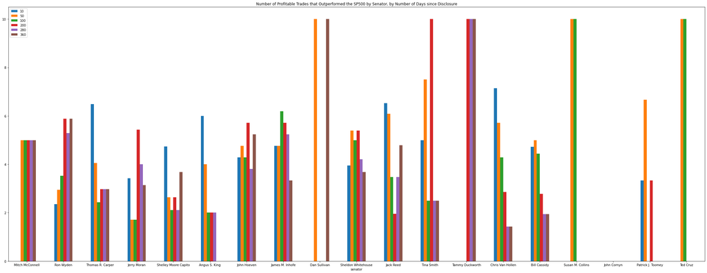

```python
# Value Counts for senators who profited + ouperformed the market
best_senators10 = disclosures[disclosures['10'] == 'trade']['senator'].value_counts()
best_senators50 = disclosures[disclosures['50'] == 'trade']['senator'].value_counts()
best_senators100 = disclosures[disclosures['100'] == 'trade']['senator'].value_counts()
best_senators200 = disclosures[disclosures['200'] == 'trade']['senator'].value_counts()
best_senators280 = disclosures[disclosures['280'] == 'trade']['senator'].value_counts()
best_senators360 = disclosures[disclosures['360'] == 'trade']['senator'].value_counts()

# Empty arrays to store counts for dataframe
array10 = []
array50 = []
array100 = []
array200 = []
array280 = []
array360 = []

# Arrays of arrays to iterate through
best_senators_array = [best_senators10, best_senators50, best_senators100, best_senators200,
                       best_senators280, best_senators360]

spans_array = [array10, array50, array100, array200, array280, array360]

# Total number of trades by senator to normalize counts by
total_trades = disclosures['senator'].value_counts()
total_trades_array = []

# Empty dataframe indexed by senaror
best_senators_df = pd.DataFrame()
best_senators_df['senator'] = disclosures['senator'].unique()
best_senators_df = best_senators_df.set_index('senator')

# Store value counts in arrays by time span
for index, row in best_senators_df.iterrows():

  total_trades_array.append(total_trades[index])

  for i in range(len(best_senators_array)):
    try:
      spans_array[i].append(best_senators_array[i][index])
    except:
      spans_array[i].append(0)

# Insert as columns into dataframe
best_senators_df['10'] = array10
best_senators_df['50'] = array50
best_senators_df['100'] = array100
best_senators_df['200'] = array200
best_senators_df['280'] = array280
best_senators_df['360'] = array360

# Normalize by total trades
best_senators_df['total_trades'] = total_trades_array

best_senators_df['10'] = (best_senators_df['10'] / best_senators_df['total_trades']) * 10
best_senators_df['50'] = (best_senators_df['50'] / best_senators_df['total_trades']) * 10
best_senators_df['100'] = (best_senators_df['100'] / best_senators_df['total_trades']) * 10
best_senators_df['200'] = (best_senators_df['200'] / best_senators_df['total_trades']) * 10
best_senators_df['280'] = (best_senators_df['280'] / best_senators_df['total_trades']) * 10
best_senators_df['360'] = (best_senators_df['360'] / best_senators_df['total_trades']) * 10

best_senators_df = best_senators_df.drop(['total_trades'], axis=1)

# Plot bar
best_senators_df.plot(kind='bar', rot=0, xlabel='senator', title='Number of Profitable Trades that Outperformed the SP500 by Senator, by Number of Days since Disclosure', figsize=(40, 15))
```

## Relationship between Committe Membership, Party, and Returns

Below is a heatmap displaying the relationship between committee cembership (# of committees a senator belongs to), political party, and return on investment 100 days out from disclosure.

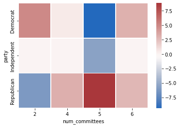

```python
heatmap_df = pd.DataFrame()

# Number of committes each senator belongs to
heatmap_df['num_committees'] = (disclosures['Committee on Appropriations'] + disclosures['Committee on Commerce, Science, and Transportation']
                                + disclosures['Committee on Health, Education, Labor, and Pensions'] + disclosures['Committee on Energy and Natural Resources']
                                + disclosures['Committee on Foreign Relations'] + disclosures['Committee on Agriculture, Nutrition, and Forestry']
                                + disclosures['Select Committee on Intelligence'] + disclosures['Committee on Armed Services'] +  disclosures['Committee on the Judiciary']
                                + disclosures['Committee on Veterans\' Affairs'] + disclosures['Commission on Security and Cooperation in Europe']
                                + disclosures['Special Committee on Aging'] + disclosures['United States Senate Caucus on International Narcotics Control']
                                + disclosures['United States Senate Caucus on International Narcotics Control'] + disclosures['Committee on Rules and Administration']
                                + disclosures['Joint Committee on Printing'] + disclosures['Committee on Small Business and Entrepreneurship']
                                + disclosures['Committee on Environment and Public Works'] + disclosures['Committee on the Budget']
                                + disclosures['Committee on Banking, Housing, and Urban Affairs'] + disclosures['Committee on Indian Affairs'] + disclosures['Joint Committee on Taxation']
                                + disclosures['Committee on Homeland Security and Governmental Affairs'] + disclosures['Joint Economic Committee'] + disclosures['Select Committee on Ethics'])

heatmap_df['party'] = disclosures['party']
heatmap_df['percent_return'] = disclosure_returns['100']

heatmap_table = heatmap_df.pivot_table(index=['party'], columns=['num_committees'], values='percent_return', fill_value=0)

sns.heatmap(heatmap_table, linewidths=.5, cmap='vlag')
```

# 4. Modeling <>

## K-NN Classification Models by Time Span

Below, we built 6 different K-NN Classification Models, by time span, to predict whether a trade will outperform the market with a positive return.

```python
# Splitting data
disclosures_train = disclosures[:len(disclosures)//2]
disclosures_test = disclosures[((len(disclosures)//2)):]
```

```python
# optimal features
features = ['state', 'party']

X_train_dict = disclosures_train[features].to_dict(orient="records")

# Models by time span
y_train_10 = disclosures_train['10']
y_train_50 = disclosures_train['50']
y_train_100 = disclosures_train['100']
y_train_200 = disclosures_train['200']
y_train_280 = disclosures_train['280']
y_train_360 = disclosures_train['360']

y_test_10 = disclosures_test['10']
y_test_50 = disclosures_test['50']
y_test_100 = disclosures_test['100']
y_test_200 = disclosures_test['200']
y_test_280 = disclosures_test['280']
y_test_360 = disclosures_test['360']

scaler = StandardScaler()
model = KNeighborsClassifier(n_neighbors=5)

# Model
def pred_class(X_train_dict, y_train, p):

    vec = DictVectorizer(sparse=False)
    vec.fit(X_train_dict)
    X_train = vec.transform(X_train_dict)

    scaler.fit(X_train)
    X_train_sc = scaler.transform(X_train)

    model.fit(X_train_sc, y_train)

    pred = model.predict(X_train_sc)
    prob = model.predict_proba(X_train_sc)

    if (p < 1):
      return pred

    else:
      return prob

# Predictions by time span
y_pred_10 = pred_class(X_train_dict, y_train_10, 0)
y_pred_50 = pred_class(X_train_dict, y_train_50, 0)
y_pred_100 = pred_class(X_train_dict, y_train_100, 0)
y_pred_200 = pred_class(X_train_dict, y_train_200, 0)
y_pred_280 = pred_class(X_train_dict, y_train_280, 0)
y_pred_360 = pred_class(X_train_dict, y_train_360, 0)
```

# Models' Train and Test Error

Below, we calculated the train and test error across all models.

```python
# Train accuracy
train_accuracy_10 = accuracy_score(y_train_10, y_pred_10)
train_accuracy_50 = accuracy_score(y_train_50, y_pred_50)
train_accuracy_100 = accuracy_score(y_train_100, y_pred_100)
train_accuracy_200 = accuracy_score(y_train_200, y_pred_200)
train_accuracy_280 = accuracy_score(y_train_280, y_pred_280)
train_accuracy_360 = accuracy_score(y_train_360, y_pred_360)

print("10 day model train accuracy: ", train_accuracy_10)
print("50 day model train accuracy: ", train_accuracy_50)
print("100 day model train accuracy: ", train_accuracy_100)
print("200 day model train accuracy: ", train_accuracy_200)
print("280 day model train accuracy: ", train_accuracy_280)
print("360 day model train accuracy: ", train_accuracy_360)
```

```
10 day model train accuracy:  0.5748502994011976
50 day model train accuracy:  0.5568862275449101
100 day model train accuracy:  0.6047904191616766
200 day model train accuracy:  0.41916167664670656
280 day model train accuracy:  0.5329341317365269
360 day model train accuracy:  0.46107784431137727
```

```python
# Test Accuracy
pipeline = Pipeline([
    ("scaler", scaler),
    ("model", model)
])

vec = DictVectorizer(sparse=False)
vec.fit(X_train_dict)
X_train = vec.transform(X_train_dict)

test_accuracy_10 = (cross_val_score(pipeline, X_train, y_test_10,
                    cv=5, scoring="accuracy")).mean()

test_accuracy_50 = (cross_val_score(pipeline, X_train, y_test_50,
                    cv=5, scoring="accuracy")).mean()

test_accuracy_100 = (cross_val_score(pipeline, X_train, y_test_100,
                    cv=5, scoring="accuracy")).mean()

test_accuracy_200 = (cross_val_score(pipeline, X_train, y_test_200,
                    cv=5, scoring="accuracy")).mean()

test_accuracy_280 = (cross_val_score(pipeline, X_train, y_test_280,
                    cv=5, scoring="accuracy")).mean()

test_accuracy_360 = (cross_val_score(pipeline, X_train, y_test_360,
                    cv=5, scoring="accuracy")).mean()


print("\n10 day model test accuracy: ", test_accuracy_10)
print("50 day model test accuracy: ", test_accuracy_50)
print("100 day model test accuracy: ", test_accuracy_100)
print("200 day model test accuracy: ", test_accuracy_200)
print("280 day model test accuracy: ", test_accuracy_280)
print("360 day model testaccuracy: ", test_accuracy_360)
```

```
10 day model test accuracy:  0.34884135472370764
50 day model test accuracy:  0.3598930481283423
100 day model test accuracy:  0.4368983957219251
200 day model test accuracy:  0.5324420677361854
280 day model test accuracy:  0.4910873440285205
360 day model testaccuracy:  0.6766488413547236
```

```python
# Calculating (predicted positives / all positives) for "trade"  predictions only

test_df = pd.DataFrame()
n = 100
test_df['actual_{}'.format(n)] = disclosures_test['{}'.format(n)]
test_df['pred_{}'.format(n)] = y_pred_100
test_df_slice = test_df[test_df['actual_{}'.format(n)] == "trade"]

print('% of trades that beat the market that our model caught')
print(100*test_df_slice['pred_{}'.format(n)].value_counts()['trade'] / test_df_slice['pred_{}'.format(n)].value_counts().sum())
```

```
% of trades that beat the market that our model caught
28.169014084507044
```

```python
# Calculating (true positives / predicted positives) for "trade" predictions only

print('% of the trades our model tells us to make that actually beat the market')
print(100*test_df_slice['pred_{}'.format(n)].value_counts()['trade'] / test_df['pred_{}'.format(n)].value_counts()['trade'])
```

```
% of the trades our model tells us to make that actually beat the market
43.47826086956522
```

# Confidence

```python
y_prob_100 = pred_class(X_train_dict, y_train_100, 1)

disclosures_test_copy = disclosures_test

p_array = []
q_array = []

for i in range(len(y_prob_100)):

  p = y_prob_100[i][1]
  q = y_prob_100[i][0]

  p_array.append(p)
  q_array.append(q)


disclosures_test_copy['pred'] = y_pred_100
disclosures_test_copy['p'] = p_array
disclosures_test_copy['q'] = q_array

disclosures_test_copy = disclosures_test_copy[disclosures_test_copy['pred'] == 'trade']
```

```
average percent gain for a suggested action @: 0.6 -0.07352002827481506
average percent gain for a suggested action @: 0.8 -0.07352002827481506
average percent gain for a suggested action @: 1.0 -0.07352002827481506
```

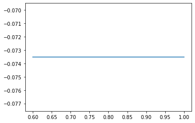

```python
## Plot Returns of Predictions v.s. Confidence
all = []

# iterate through confidence values returned
confs = [0.6, 0.8, 1.0]
for conf in confs:
  trades = []
  for i in range(len(disclosures_test_copy[disclosures_test_copy['p'] == conf])-1):
    trade = disclosures_test_copy[disclosures_test_copy['p'] == conf].loc[disclosures_test_copy[disclosures_test_copy['p'] == conf].index[i]]
    ti = trade['ticker']
    st = trade['transaction_date']
    en = trade['transaction_date'] + timedelta(days=10)
    if trade['type'] == 'Purchase':
      trades.append(100*((disclosure_data[ti][st:en][len(disclosure_data[ti][st:en])-1] - disclosure_data[ti][st:en][0])/disclosure_data[ti][st:en][0]))
    else:
      trades.append(-100*((disclosure_data[ti][st:en][len(disclosure_data[ti][st:en])-1] - disclosure_data[ti][st:en][0])/disclosure_data[ti][st:en][0]))
    avg = np.average(trades)
  print('average percent gain for a suggested action @:', conf, avg)
  all.append(avg)
plt.plot(confs, all)
```

# 5. Conclusion < >

While our analysis is far from done, we are happy to have been able to find so much in this data.

Whenever we included some of the more unique features, like herding, our model would overfit to our limited data. We hope to continue improving upon this strategy and working towards a better model as our dataset grows with time.